# Exercise - The Briscola Game

Nicholas Pearson

2025-09-10

## The Briscola Game

Briscola is a popular italian card game. It is played with a deck of cards of the following form:

- there are four seeds: Sticks (Bastoni), Coins (Denari), Cups (Coppe) and Swards (Spade)
- for each seed there are 10 cards: Ace (11 points), Three (10 points), King (4 Points), Knight (3 points), Jack (2 points) and then Seven, Six, Five, Four, Two (0 points each)

At the start of each game, one card is randomly extracted and its seed becomes the Briscola (the dominant seed for the game).

1. Create the deck of cards in R.

```r
seeds <- c("Sticks", "Coins", "Cups", "Swards")
numbers <- c("Ace", "Three", "King", "Knight", "Jack", "Seven", "Six", "Five", "Four", "Two")

deck <- expand.grid(number = numbers, suit = seeds)
deck <- with(deck, paste(number, suit))

deck
```

```
##  [1] "Ace Sticks"    "Three Sticks"  "King Sticks"   "Knight Sticks"
##  [5] "Jack Sticks"   "Seven Sticks"  "Six Sticks"    "Five Sticks"
##  [9] "Four Sticks"   "Two Sticks"    "Ace Coins"     "Three Coins"
## [13] "King Coins"    "Knight Coins"  "Jack Coins"    "Seven Coins"
## [17] "Six Coins"     "Five Coins"    "Four Coins"    "Two Coins"
## [21] "Ace Cups"      "Three Cups"    "King Cups"     "Knight Cups"
## [25] "Jack Cups"     "Seven Cups"    "Six Cups"      "Five Cups"
## [29] "Four Cups"     "Two Cups"      "Ace Swards"    "Three Swards"
## [33] "King Swards"   "Knight Swards" "Jack Swards"   "Seven Swards"
## [37] "Six Swards"    "Five Swards"   "Four Swards"   "Two Swards"
```

2. What is the probability that the Briscola is “Coins”? And that it is not “Coins”?

```r
coins <- paste(numbers, "Coins")

prob_briscola_coins <- mean(deck %in% coins)
prob_briscola_coins
```

```
## [1] 0.25
```

```r
prob_briscola_coins == 1/length(seeds) #one seed over the four possible ones
```

```
## [1] TRUE
```

```r
prob_briscola_no_coins <- 1 - prob_briscola_coins
prob_briscola_no_coins
```

```
## [1] 0.75
```

Assume now that you are working with the full 40 card deck (no Briscola draw).

3. What is the probability of drawing an Ace?

```r
aces <- paste("Ace", seeds)

prob_ace_first <- mean(deck %in% aces)
prob_ace_first
```

```
## [1] 0.1
```

```r
prob_ace_first == 1/length(numbers) #one card over the ten possible cards (for each seed)
```

```
## [1] TRUE
```

4. Consider the drawing of two cards. What is the probability of drawing as second card an Ace knowing that the first card was not an Ace?

```r
library(gtools)

# All possible ways to draw two cards (the order matters)
hands <- permutations(40, 2, v = deck)

# Extract first and second cards
first_card <- hands[, 1]
second_card <- hands[, 2]

not_aces <- deck[!(deck %in% aces)]
not_aces
```

```
##  [1] "Three Sticks"  "King Sticks"   "Knight Sticks" "Jack Sticks"
##  [5] "Seven Sticks"  "Six Sticks"    "Five Sticks"   "Four Sticks"
##  [9] "Two Sticks"    "Three Coins"   "King Coins"    "Knight Coins"
## [13] "Jack Coins"    "Seven Coins"   "Six Coins"     "Five Coins"
## [17] "Four Coins"    "Two Coins"     "Three Cups"    "King Cups"
## [21] "Knight Cups"   "Jack Cups"     "Seven Cups"    "Six Cups"
## [25] "Five Cups"     "Four Cups"     "Two Cups"      "Three Swards"
## [29] "King Swards"   "Knight Swards" "Jack Swards"   "Seven Swards"
## [33] "Six Swards"    "Five Swards"   "Four Swards"   "Two Swards"
```

```r
prob_not_ace <- 1 - prob_ace_first

prob_ace_second <- mean(second_card %in% aces & first_card %in% not_aces)/prob_not_ace
prob_ace_second
```

```
## [1] 0.1025641
```

```r
prob_ace_second == 4/39 #once the first card is drawn, there are 39 cards left in the deck and the aces are still 4
```

```
## [1] TRUE
```

5. Consider the drawing of two cards. What is the probability of drawing two cards such that the sum of the corresponding points is zero?

```r
points <- c(11, 10, 4, 3, 2, 0, 0, 0, 0, 0)
deck_points <- rep(points, 4)

hands_points <- permutations(length(deck_points), 2, v = deck_points, set=FALSE, repeats.allowed = FALSE)
first_card_points <- hands_points[,1]
second_card_points <- hands_points[,2]

sum_points <- first_card_points + second_card_points

zero_points <- mean(sum_points == 0)
zero_points
```

```
## [1] 0.2435897
```

```r
zero_points == (20/40)*(19/39) #the probability of extracting one card that does not hold point is 20/40 (half of the deck), then the second draw is over 39 cards and those not holding points are 20-1=19
```

```
## [1] TRUE
```

6. Consider the drawing of two cards. What is the probability of drawing two cards such that the sum of the corresponding points is five?

```r
five_points <- mean(sum_points == 5)
five_points
```

```
## [1] 0.02051282
```

```r
five_points == (8/40)*(4/39) #the first card can be either a knight or a jack (8 cards in total) over the 40 possible ones. Once the card has been extracted, only the 4 cards of the other figure are available (over 39)
```

```
## [1] TRUE
```

The game of Briscola works with hands of three cards per player. Assume that you are drawing the first three cards for yourself (the opposite player’s hand and the Briscola card will be drawn after your hand).

7. What is the probability of drawing at least one card that holds points?

```r
hands_3_points <- permutations(40, 3, v=deck_points, set=FALSE, repeats.allowed = FALSE)

sum_3_points <- hands_3_points[,1] + hands_3_points[,2] + hands_3_points[,3]

one_card_points <- mean(sum_3_points>0)
one_card_points
```

```
## [1] 0.8846154
```

```r
one_card_points == (1-(20/40)*(19/39)*(18/38)) #we compute the probability of getting three cards with zero points (as above)
```

```
## [1] TRUE
```

8. What is the probability of drawing three Aces?

```r
three_aces <- mean(sum_3_points == 33)
three_aces
```

```
## [1] 0.0004048583
```

```r
three_aces == ((4/40) * (3/39) * (2/38)) #for the first draw there are 4 aces over 40 cards. If one Ace is extracted, there are 3 aces remaining over 29 cards and - in the third draw - there are 2 aces over 38 cards
```

```
## [1] TRUE
```

9. What is the probability of drawing three cards of the same seed?

```r
deck_seeds <- rep(seeds, 10)

hands_seeds <- permutations(length(deck_seeds), 3, v = deck_seeds, set=FALSE, repeats.allowed = FALSE)
first_card_seeds <- hands_seeds[,1]
second_card_seeds <- hands_seeds[,2]
third_card_seeds <- hands_seeds[,3]

first_pair <- first_card_seeds == second_card_seeds
second_pair <- second_card_seeds == third_card_seeds

same_seed <- mean((first_pair+second_pair)==2)
same_seed
```

```
## [1] 0.048583
```

```r
same_seed == ((9/39)*(8/38))  # once the first card has been extracted, there remain 9 cards of the same seed over 39 cards, and at the third extraction there will be 8 cards remaining of that seed over 38 cards
```

```
## [1] TRUE
```

10. Consider now all the possible combinations of points that you can observe in a three cards draw. Compute the corresponding frequencies and plot the results with an appropriate graph.

```r
abs_freq <- table(sum_3_points)
abs_freq
```

```
## sum_3_points
##    0    2    3    4    5    6    7    8    9   10   11   12   13   14   15   16
## 6840 4560 4560 5280 1920 2664 2064 1008  408 4848 4704 1944 3840 3984 2448  912
##   17   18   19   20   21   22   23   24   25   26   30   31   32   33
##  912  528  144  720 1920  864  528  672  528  144   24  144  144   24
```

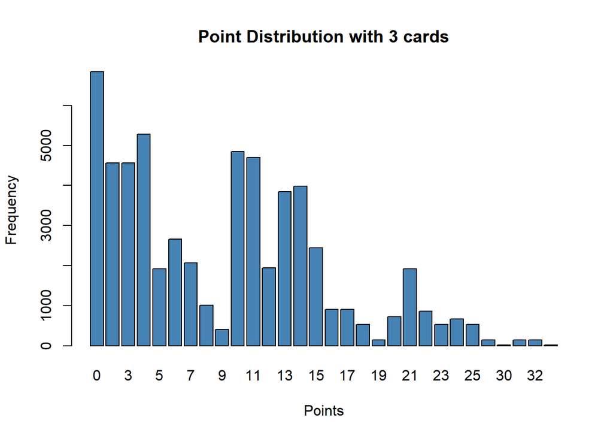

```r
barplot(abs_freq, main="Point Distribution with 3 cards", xlab="Points", ylab="Frequency", col ="steelblue")
```

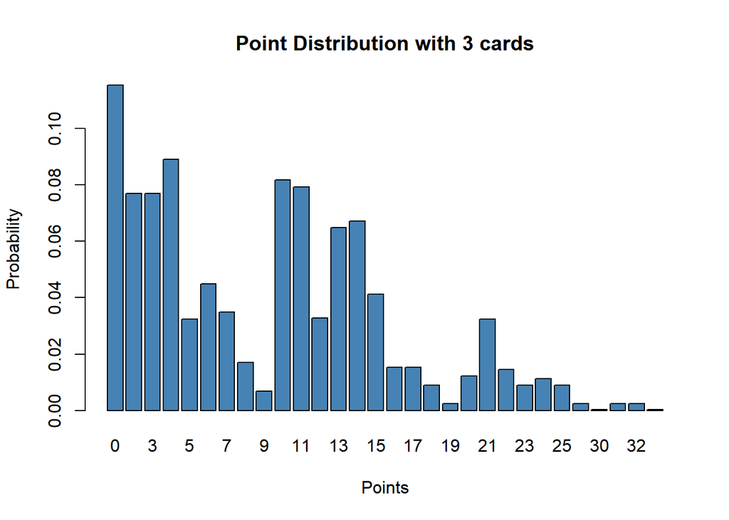

```r
prob <- prop.table(abs_freq)
barplot(prob, main="Point Distribution with 3 cards", xlab="Points", ylab="Probability", col ="steelblue")
```